# Red Wine Quality EDA by Sergii Bondariev

```
## 'data.frame':    1599 obs. of  13 variables:
##  $ X                   : int  1 2 3 4 5 6 7 8 9 10 ...
##  $ fixed.acidity       : num  7.4 7.8 7.8 11.2 7.4 7.4 7.9 7.3 7.8 7.5 ...
##  $ volatile.acidity    : num  0.7 0.88 0.76 0.28 0.7 0.66 0.6 0.65 0.58 0.5 ...
##  $ citric.acid         : num  0 0 0.04 0.56 0 0 0.06 0 0.02 0.36 ...
##  $ residual.sugar      : num  1.9 2.6 2.3 1.9 1.9 1.8 1.6 1.2 2 6.1 ...
##  $ chlorides           : num  0.076 0.098 0.092 0.075 0.076 0.075 0.069 0.065 0.073 0.071 ...
##  $ free.sulfur.dioxide : num  11 25 15 17 11 13 15 15 9 17 ...
##  $ total.sulfur.dioxide: num  34 67 54 60 34 40 59 21 18 102 ...
##  $ density             : num  0.998 0.997 0.997 0.998 0.998 ...
##  $ pH                  : num  3.51 3.2 3.26 3.16 3.51 3.51 3.3 3.39 3.36 3.35 ...
##  $ sulphates           : num  0.56 0.68 0.65 0.58 0.56 0.56 0.46 0.47 0.57 0.8 ...
##  $ alcohol             : num  9.4 9.8 9.8 9.8 9.4 9.4 9.4 10 9.5 10.5 ...
##  $ quality             : int  5 5 5 6 5 5 5 7 7 5 ...
```

# Univariate Plots Section

Distribution of quality

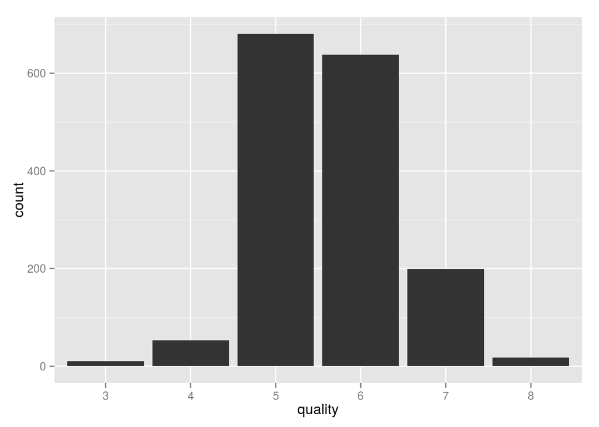

The plot above confirms that, as described in the accompanying text file, the data is not balanced. There are many more normal wines, than poor or excelent ones.

Distribution of ‘fixed.acidity’

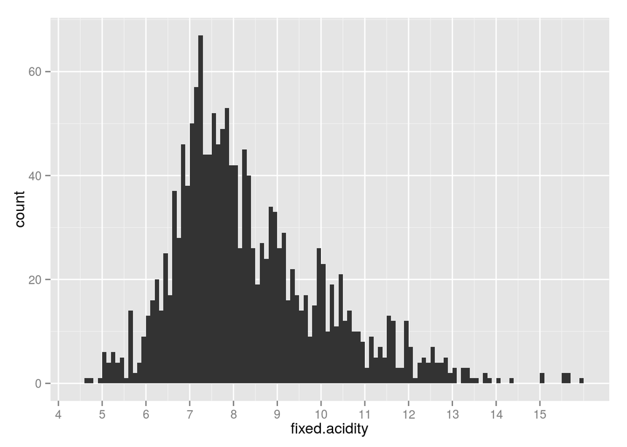

```
##    Min. 1st Qu.  Median    Mean 3rd Qu.    Max.
##    4.60    7.10    7.90    8.32    9.20   15.90
```

Most of the wines have the fixed acidity in the interval (6, 11).

Distribution of ‘volatile.acidity’

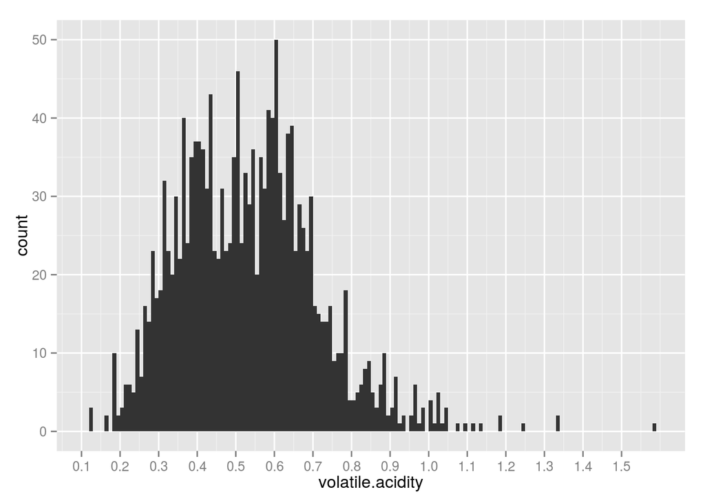

```
##    Min. 1st Qu.  Median    Mean 3rd Qu.    Max.
##  0.1200  0.3900  0.5200  0.5278  0.6400  1.5800
```

Most of the wines have the volatile acidity in the interval (0.2, 0.9).

Distribution of citric acid

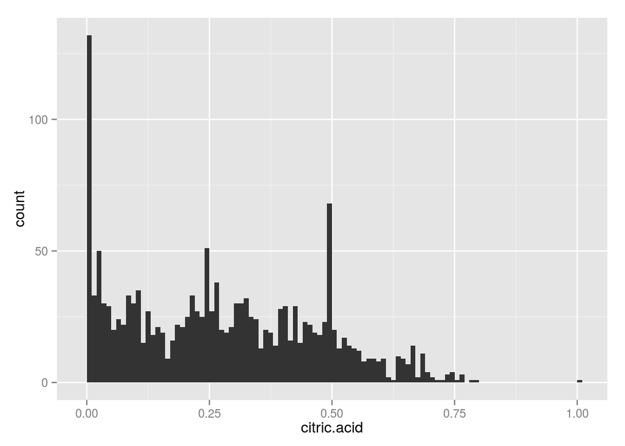

```
##    Min. 1st Qu.  Median    Mean 3rd Qu.    Max.
##   0.000   0.090   0.260   0.271   0.420   1.000
```

A big number of wines do not have the citric acid. Most of the wines have the density of the citric acid below 0.5 g/dm^3. There is an outlier (or several outliers) with the citric acid density of 1 g/dm^3.

Distribution of a residual sugar

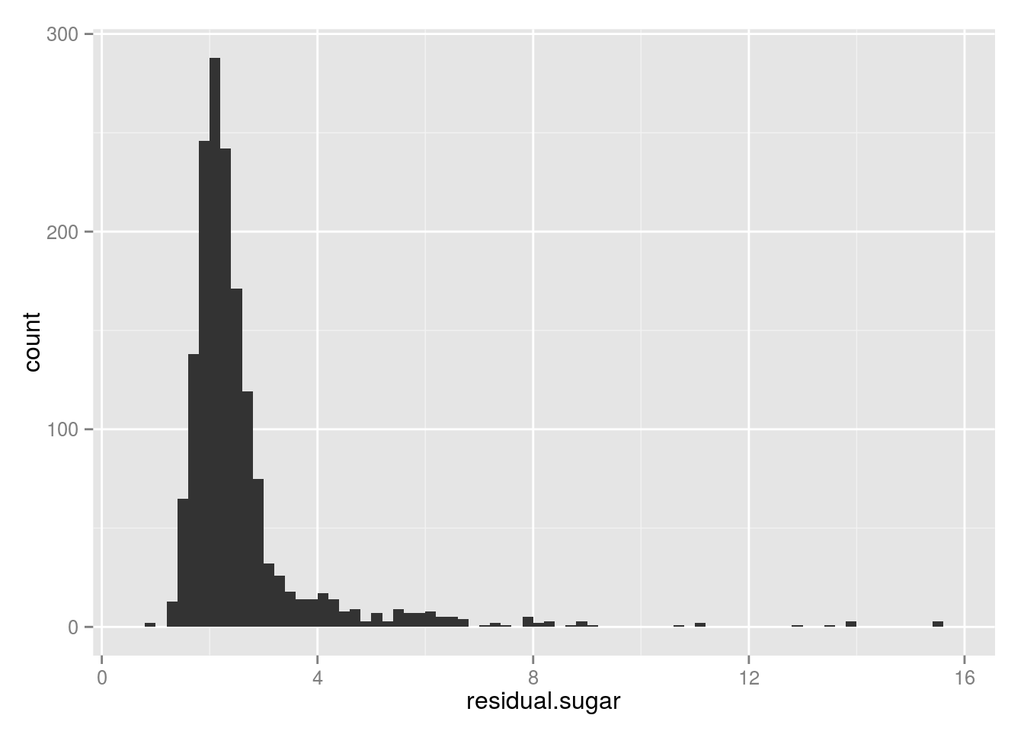

```
##    Min. 1st Qu.  Median    Mean 3rd Qu.    Max.
##   0.900   1.900   2.200   2.539   2.600  15.500
```

The distribution of a residual sugar resembles a normal distribution with a small variance, but with a long right tail. There is a number of outliers that make a tail even longer.

The distribution of chlorides

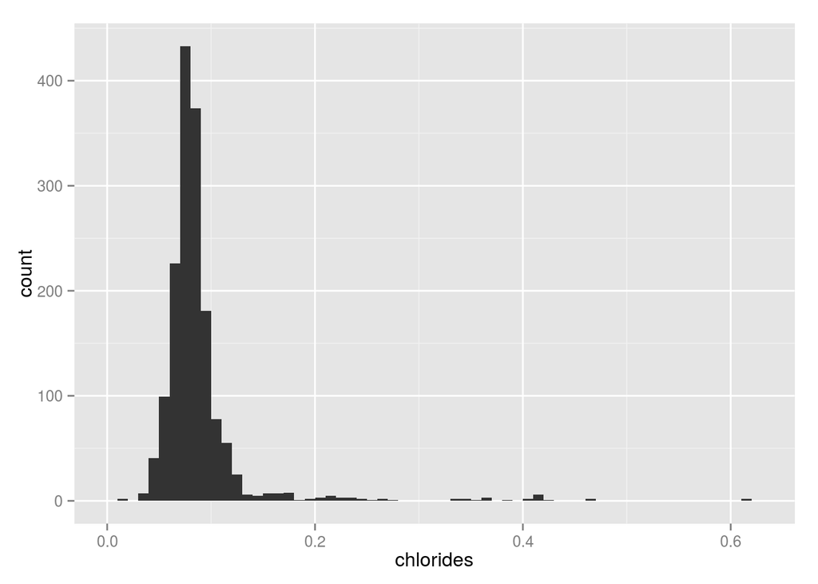

```
##    Min. 1st Qu.  Median    Mean 3rd Qu.    Max.
## 0.01200 0.07000 0.07900 0.08747 0.09000 0.61100
```

Similar to a residual sugar.

Distribution of free.sulfur.dioxide

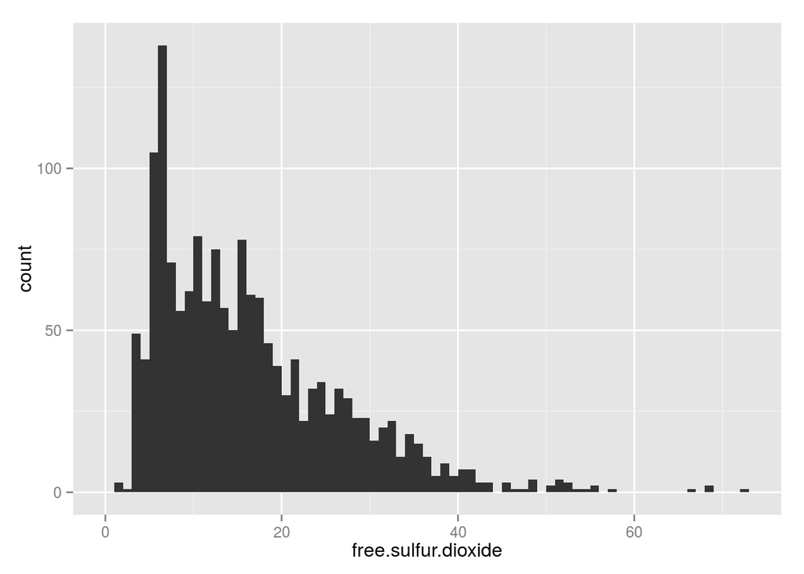

```
##    Min. 1st Qu.  Median    Mean 3rd Qu.    Max.
##    1.00    7.00   14.00   15.87   21.00   72.00
```

Distribution of total.sulfur.dioxide

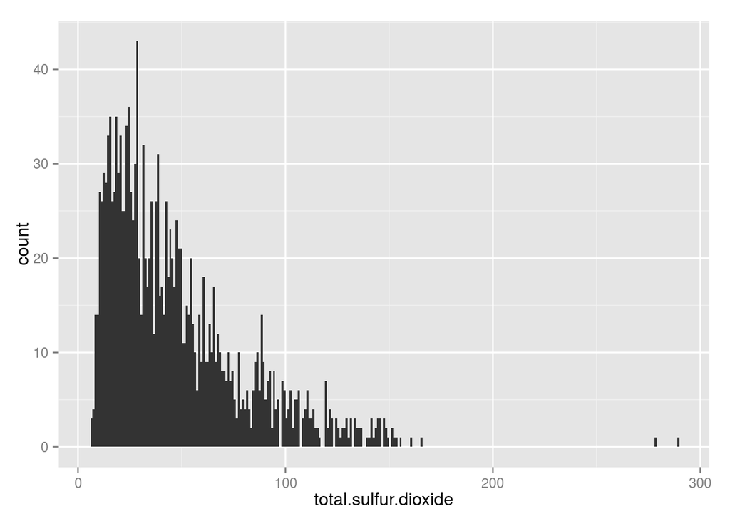

```
##    Min. 1st Qu.  Median    Mean 3rd Qu.    Max.
##    6.00   22.00   38.00   46.47   62.00  289.00
```

Distribution of (total.sulfur.dioxide - free.sulfur.dioxide)

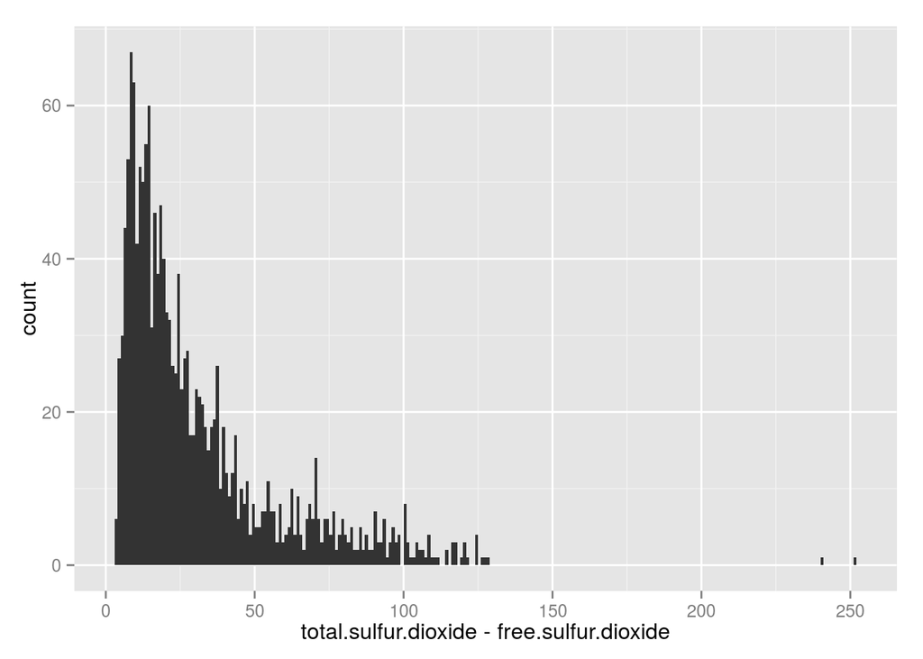

Distribution of density

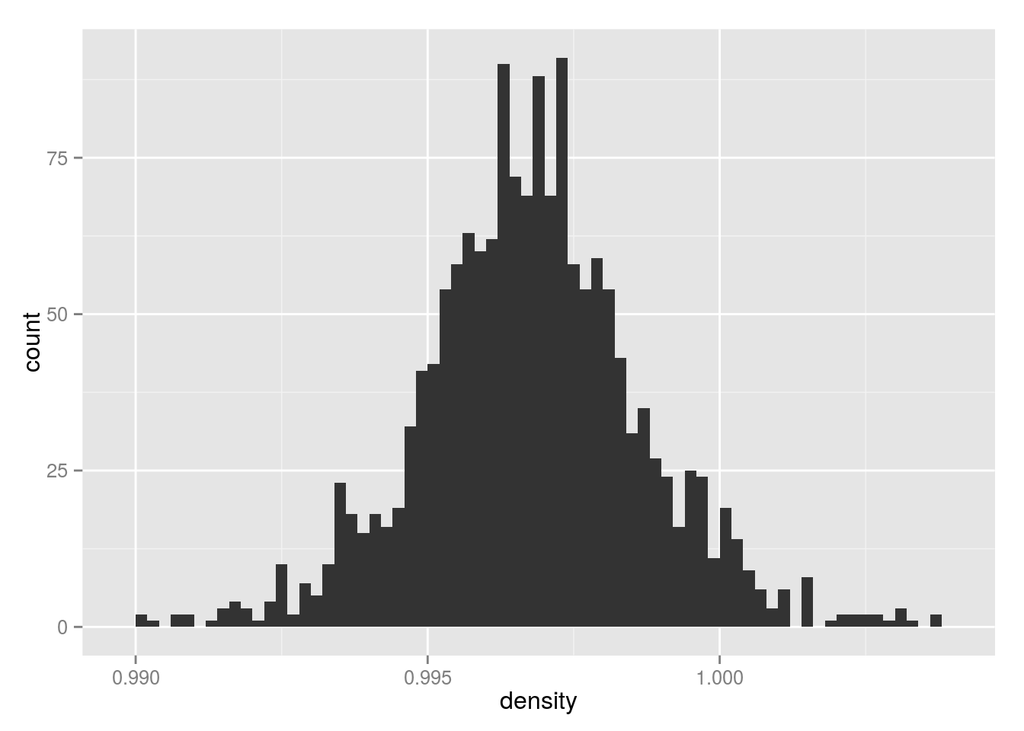

```
##    Min. 1st Qu.  Median    Mean 3rd Qu.    Max.
##  0.9901  0.9956  0.9968  0.9967  0.9978  1.0040
```

Resembles a normal distribution

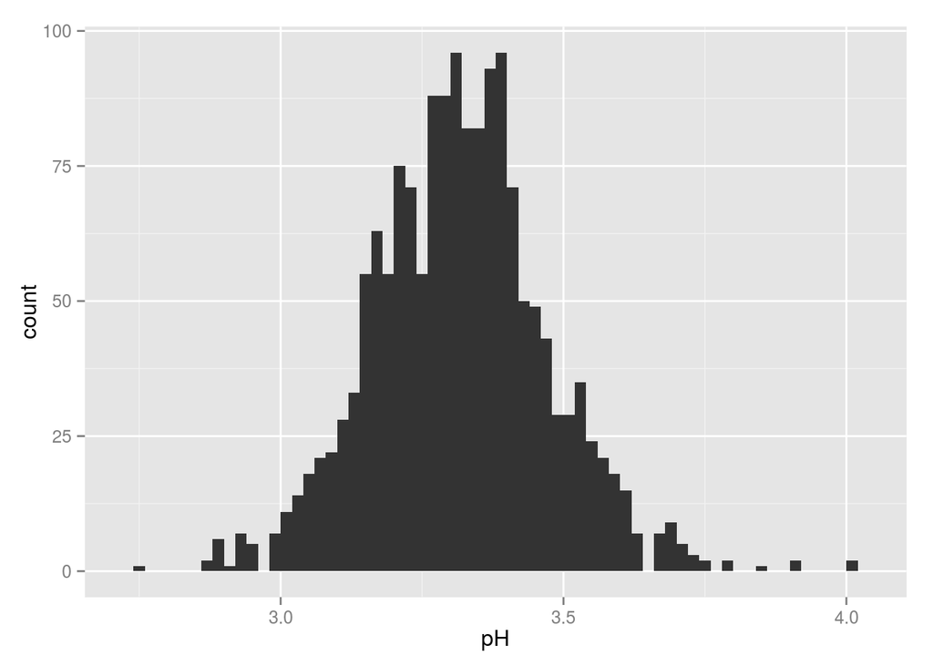

```
##    Min. 1st Qu.  Median    Mean 3rd Qu.    Max.
##   2.740   3.210   3.310   3.311   3.400   4.010
```

Resembles a normal distribution. All wines are acidic with pH between 2.7 and 4.01.

Distribution of sulphates

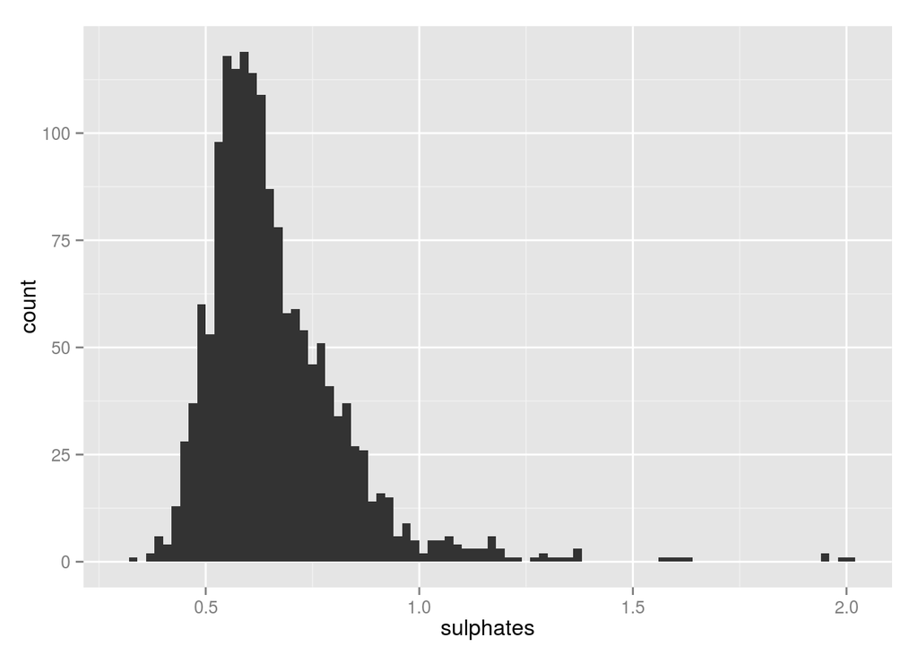

```
##    Min. 1st Qu.  Median    Mean 3rd Qu.    Max.
##  0.3300  0.5500  0.6200  0.6581  0.7300  2.0000
```

Skewed normal distribution with a long right tail and outliers.

Distribution of alcohol

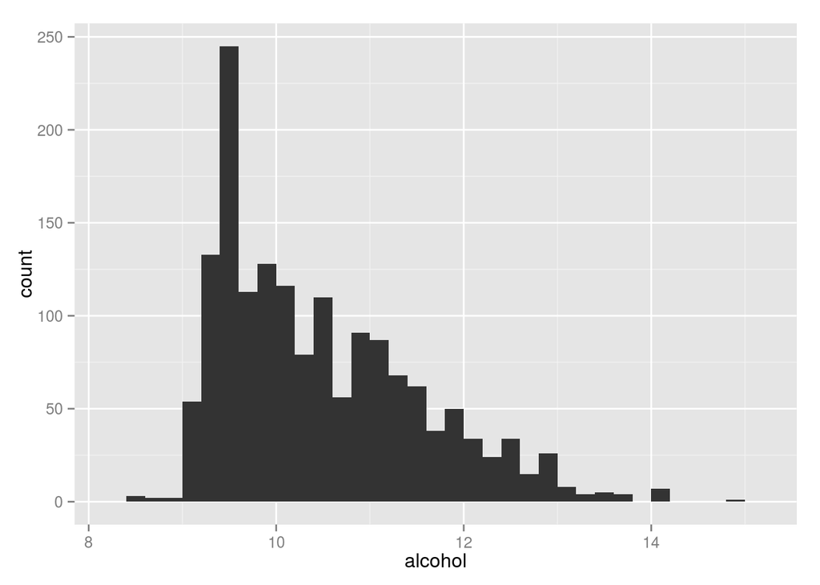

```
##    Min. 1st Qu.  Median    Mean 3rd Qu.    Max.
##    8.40    9.50   10.20   10.42   11.10   14.90
```

# Univariate Analysis

### What is the structure of your dataset?

The red wine dataset consists of 1599 observations and 13 variables. The quality was converted to a factor variable.

### What is/are the main feature(s) of interest in your dataset?

‘quality’ is the main feature, because it is a dependent variable used in training and evaluating the model, if we are interested in wine quality predictions.

### What other features in the dataset do you think will help support your investigation into your feature(s) of interest?

At this point there is no evidence to discard any of the features, except an identifier ‘X’. There is a thought that free.sulfur.dioxide and total.sulfur.dioxide could be highly correlated, because total contents of SO2 includes free SO2. That said, total.sulfur.dioxide could be neglected in the future and replaced by (total.sulfur.dioxide - free.sulfur.dioxide). However this analysis will be done in the next section.

### Did you create any new variables from existing variables in the dataset?

One variable was created along the way, (total.sulfur.dioxide - free.sulful.dioxide), to see the distribution of the bound sulfur dioxide.

### Of the features you investigated, were there any unusual distributions? Did you perform any operations on the data to tidy, adjust, or change the form of the data? If so, why did you do this?

One unusual distribution was noticed for ‘citric.acid’ feature. So far no change of the form of the data was performed.

# Bivariate Plots Section

Scatterplot between free.sulfur.dioxide and total.sulfur.dioxide

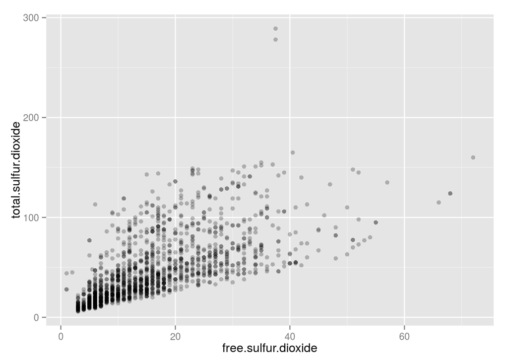

```
##
##  Pearson's product-moment correlation
##
## data:  free.sulfur.dioxide and total.sulfur.dioxide
## t = 35.84, df = 1597, p-value < 2.2e-16
## alternative hypothesis: true correlation is not equal to 0
## 95 percent confidence interval:
##  0.6395786 0.6939740
## sample estimates:
##       cor
## 0.6676665
```

We see here some correlation. It is implicitly written in the text file that free.sulfur.dioxide is included into the total.sulfur.dioxide. Let’s create a new variable, bond.sulfur.dioxide = total.sulfur.dioxide - free.sulfur.dioxide.

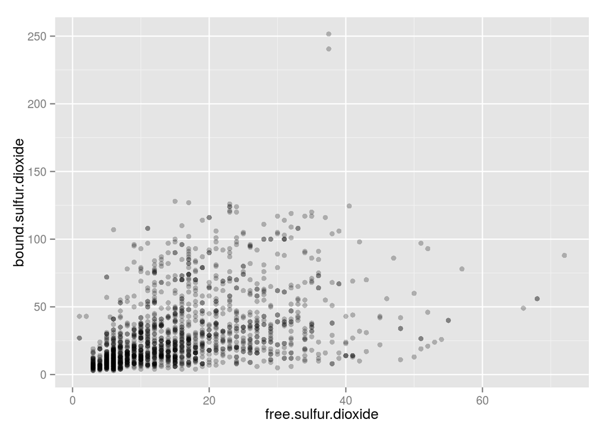

```
##
##  Pearson's product-moment correlation
##
## data:  free.sulfur.dioxide and bound.sulfur.dioxide
## t = 18.771, df = 1597, p-value < 2.2e-16
## alternative hypothesis: true correlation is not equal to 0
## 95 percent confidence interval:
##  0.3841336 0.4644895
## sample estimates:
##       cor
## 0.4251489
```

We can see this relationship has a similar shape, but a smaller correlation. In case of modeling it is better to use free.sulfur.dioxide and bound.sulfur.dioxide in place of total.sulfur.dioxide.

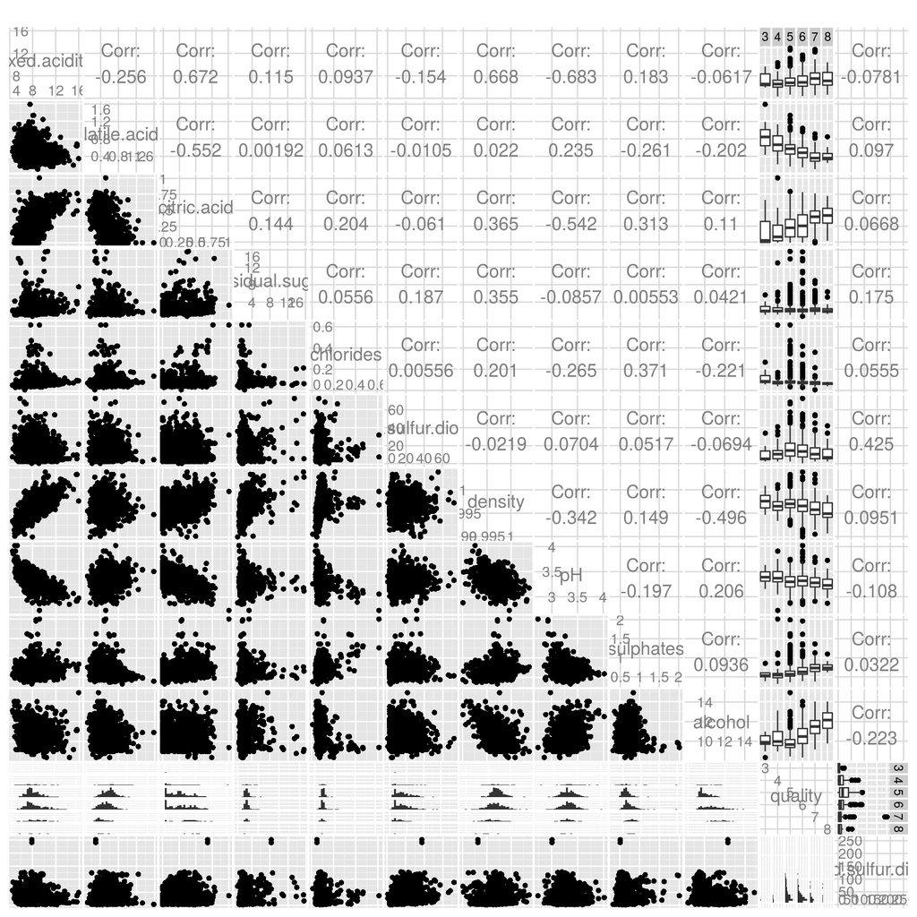

The matrix reveals some interesting relationships, for example, the ones with correlation higher than 0.5. Such cases will be examined next.

pH vs. Citric Acid

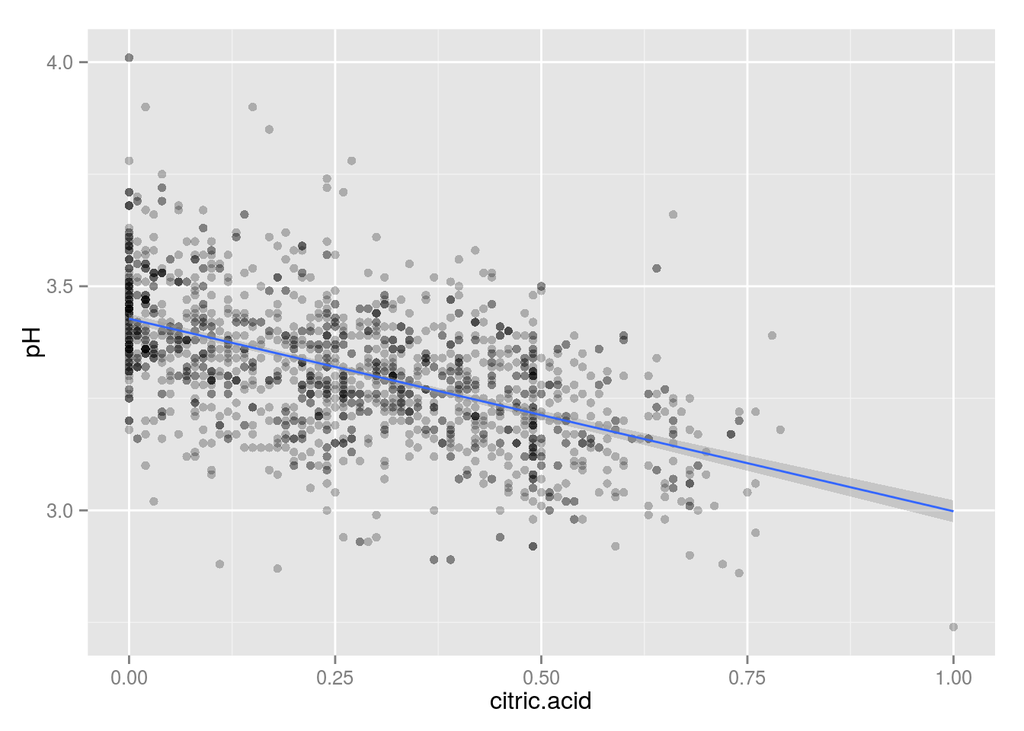

```
##
##  Pearson's product-moment correlation
##
## data:  pH and citric.acid
## t = -25.767, df = 1597, p-value < 2.2e-16
## alternative hypothesis: true correlation is not equal to 0
## 95 percent confidence interval:
##  -0.5756337 -0.5063336
## sample estimates:
##        cor
## -0.5419041
```

pH vs. Fixed Acidity

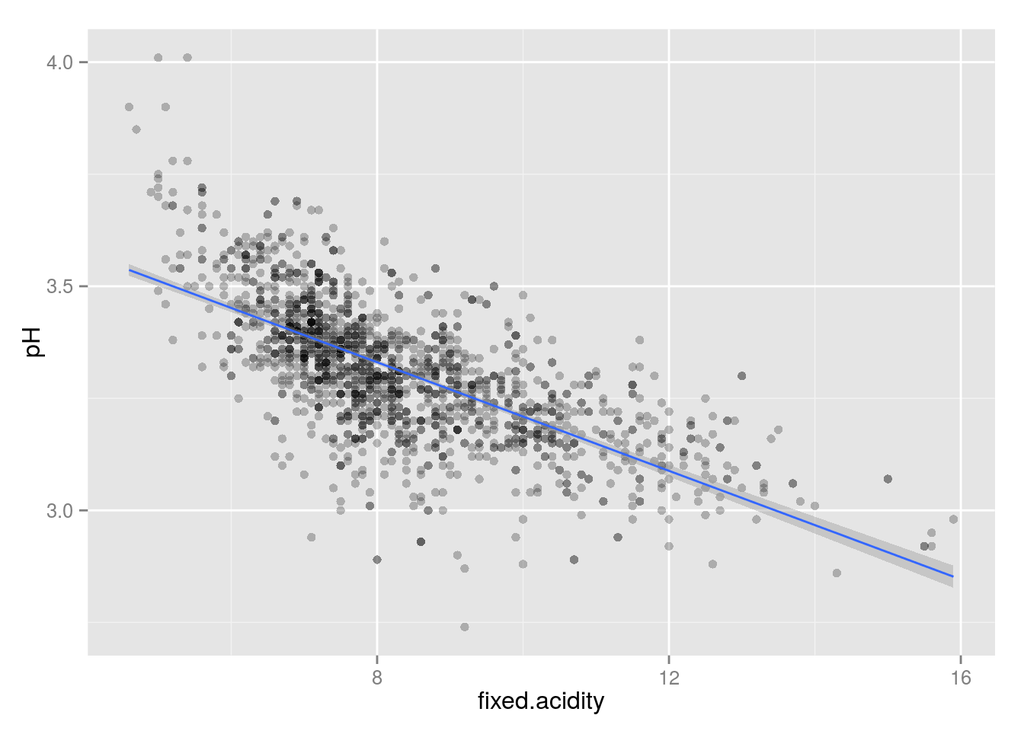

```
##
##  Pearson's product-moment correlation
##
## data:  pH and fixed.acidity
## t = -37.366, df = 1597, p-value < 2.2e-16
## alternative hypothesis: true correlation is not equal to 0
## 95 percent confidence interval:
##  -0.7082857 -0.6559174
## sample estimates:
##        cor
## -0.6829782
```

pH vs. Volatile Acidity

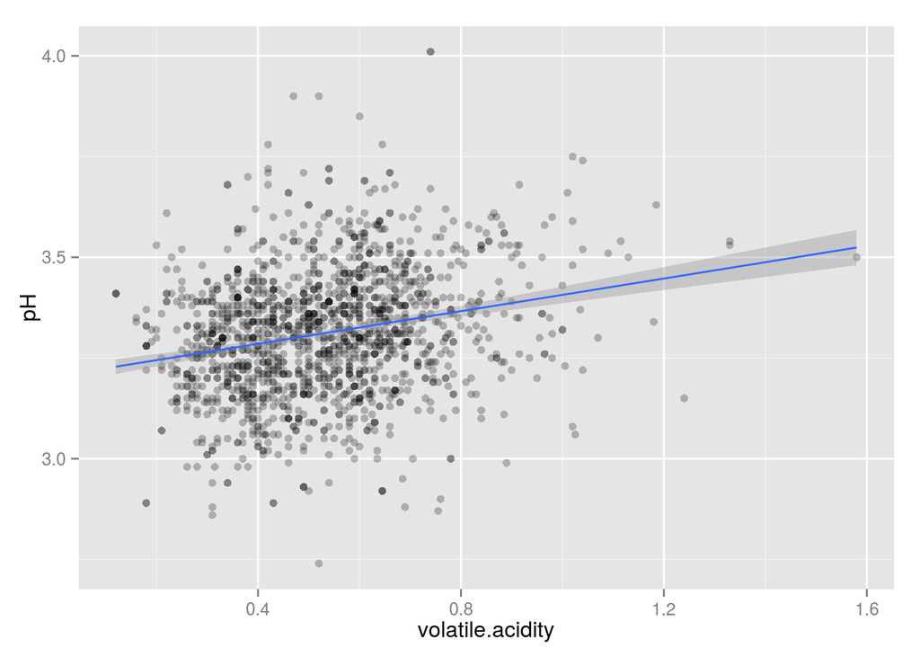

```
##
##  Pearson's product-moment correlation
##
## data:  pH and volatile.acidity
## t = 9.659, df = 1597, p-value < 2.2e-16
## alternative hypothesis: true correlation is not equal to 0
## 95 percent confidence interval:
##  0.1880823 0.2807254
## sample estimates:
##       cor
## 0.2349373
```

It is logical to see that pH decreases as citric acidity or fixed acidity increase. Also, it is likely that citric acidity is a part of a fixed acidity. Let’s check this.

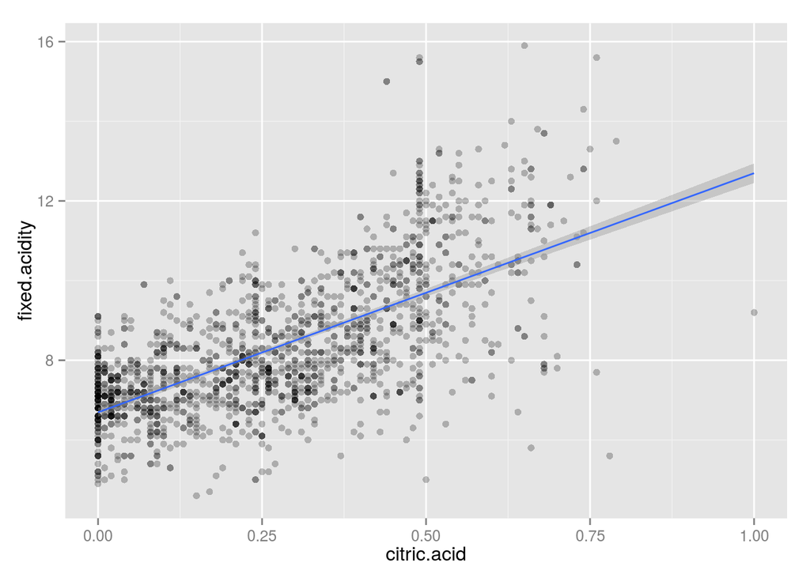

```
##
##  Pearson's product-moment correlation
##
## data:  citric.acid and fixed.acidity
## t = 36.234, df = 1597, p-value < 2.2e-16
## alternative hypothesis: true correlation is not equal to 0
## 95 percent confidence interval:
##  0.6438839 0.6977493
## sample estimates:
##       cor
## 0.6717034
```

We can see the high correlation here. Let’s verify the correlation between citric.acid and other acids in the fixed.acidity.

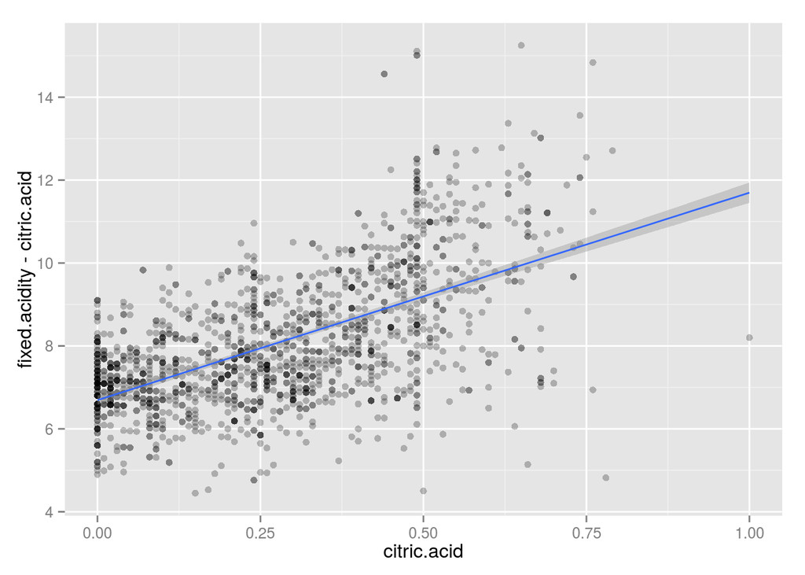

```
##
##  Pearson's product-moment correlation
##
## data:  citric.acid and fixed.acidity - citric.acid
## t = 30.199, df = 1597, p-value < 2.2e-16
## alternative hypothesis: true correlation is not equal to 0
## 95 percent confidence interval:
##  0.5707406 0.6332009
## sample estimates:
##       cor
## 0.6028937
```

We can see that correlation is only little but lower. It suggests that the wines with higher levels of citric acid will also have higher levels of other fixed acids.

We can also check if volatile acidity is correlated with a fixed acidity.

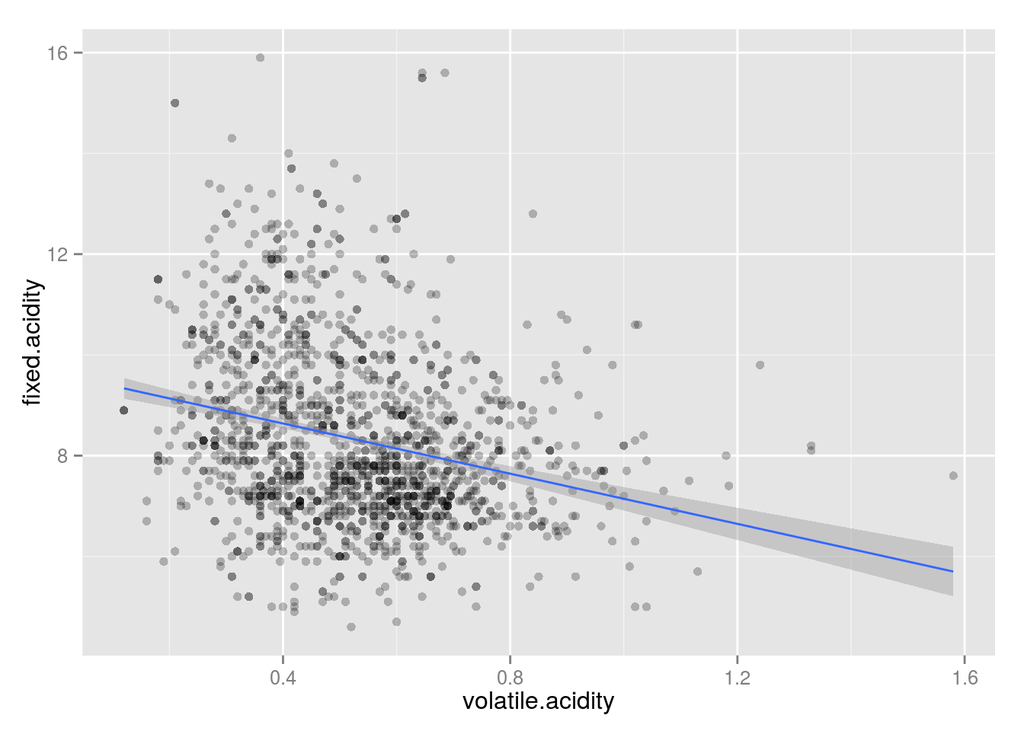

```
##
##  Pearson's product-moment correlation
##
## data:  volatile.acidity and fixed.acidity
## t = -10.589, df = 1597, p-value < 2.2e-16
## alternative hypothesis: true correlation is not equal to 0
## 95 percent confidence interval:
##  -0.3013681 -0.2097433
## sample estimates:
##        cor
## -0.2561309
```

Density vs. Fixed Acidity

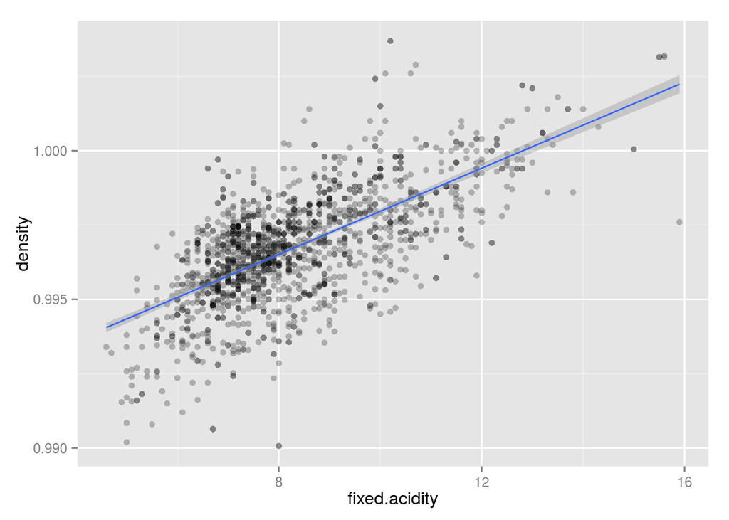

```
##
##  Pearson's product-moment correlation
##
## data:  fixed.acidity and density
## t = 35.877, df = 1597, p-value < 2.2e-16
## alternative hypothesis: true correlation is not equal to 0
## 95 percent confidence interval:
##  0.6399847 0.6943302
## sample estimates:
##       cor
## 0.6680473
```

We see a positive correlation here.

Density vs. Chlorides

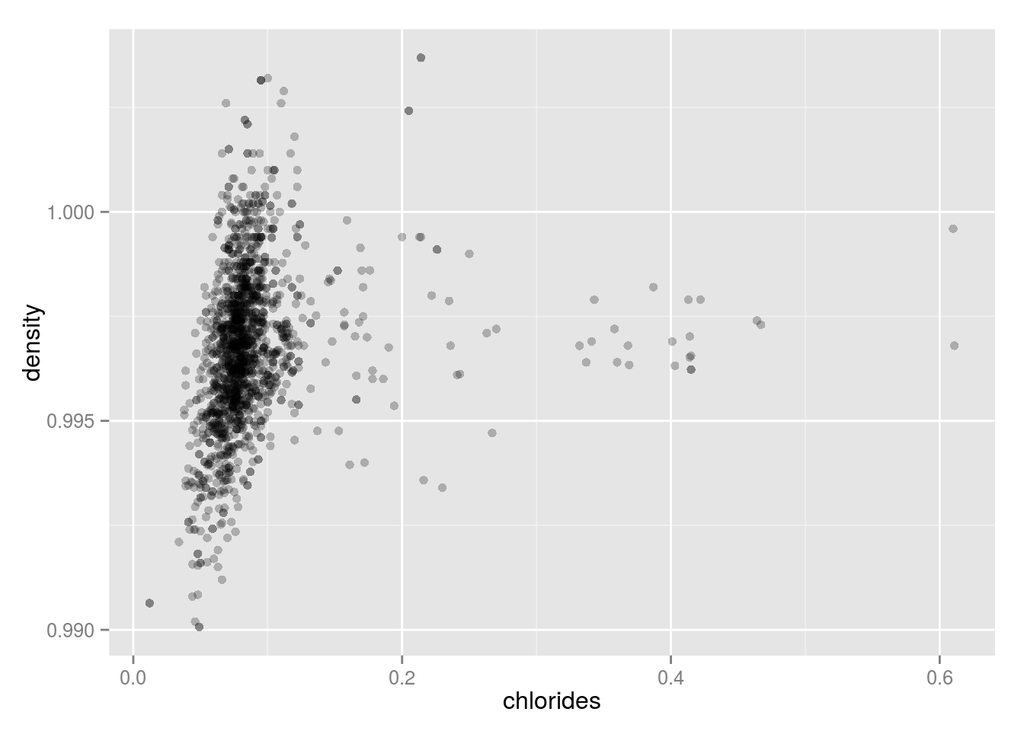

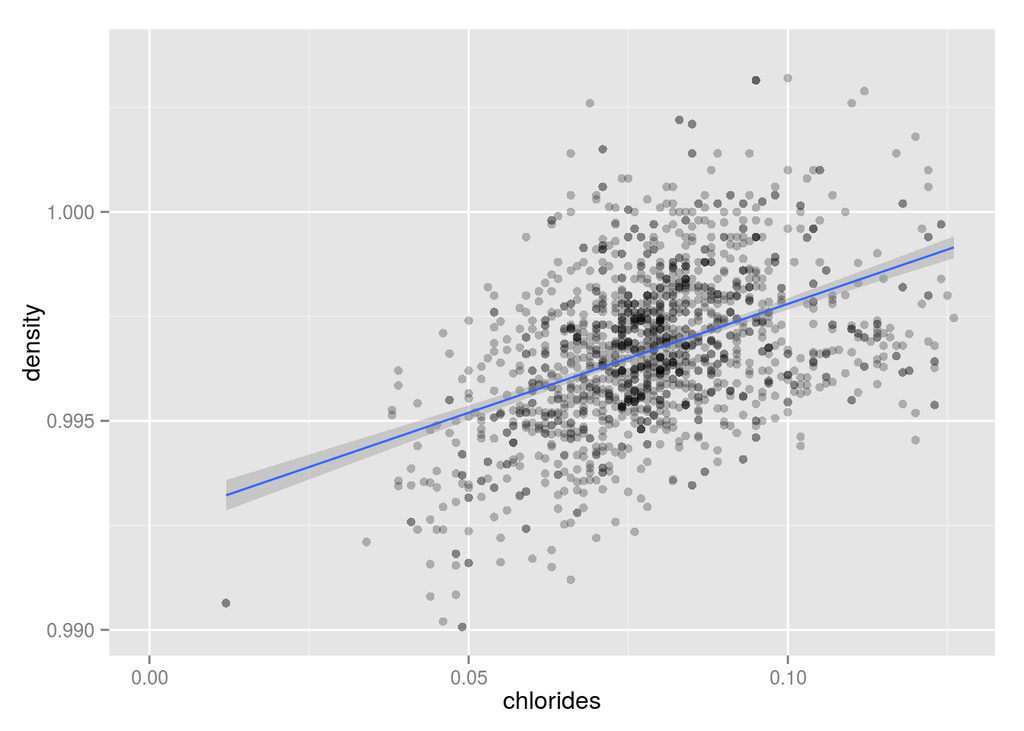

Density vs. Residual Sugar

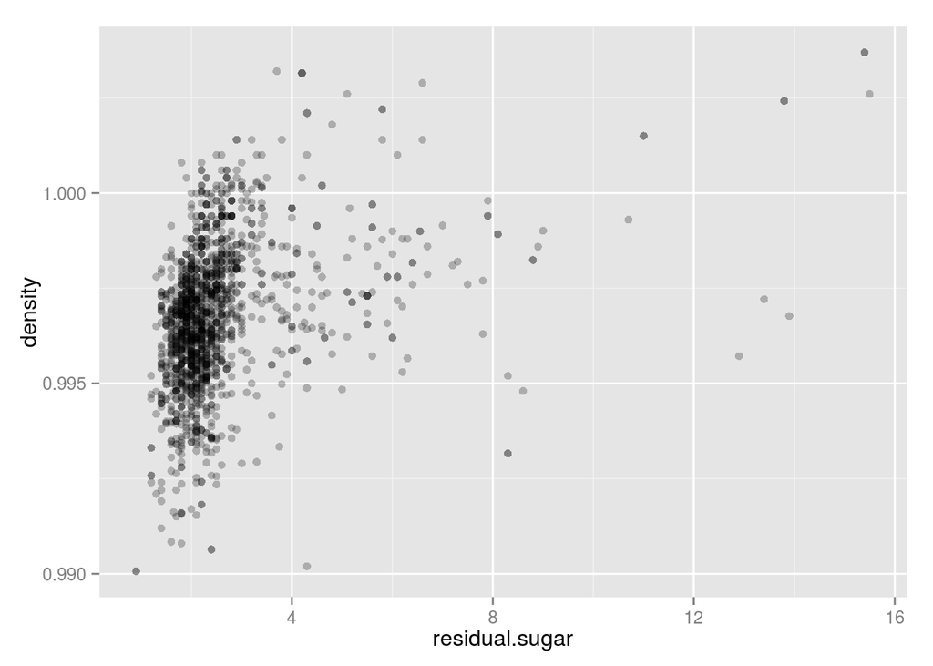

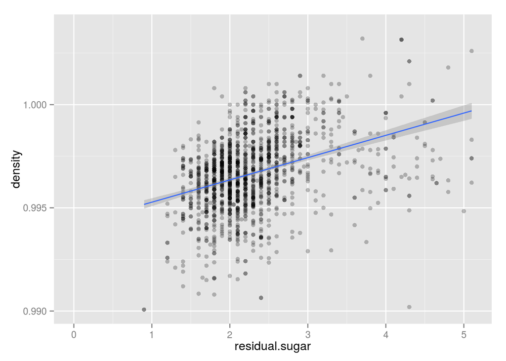

Density vs. Alcohol

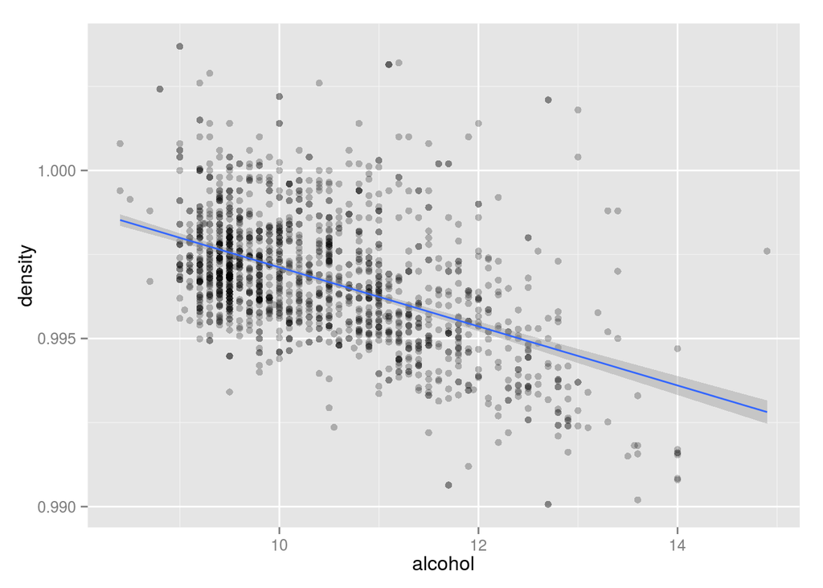

Chlorides and residual sugars both add to density, which is logical, because they are soluble in water. Wines with a higher alcohol level tend to have smaller density.

Boxplot of features per quality rating:

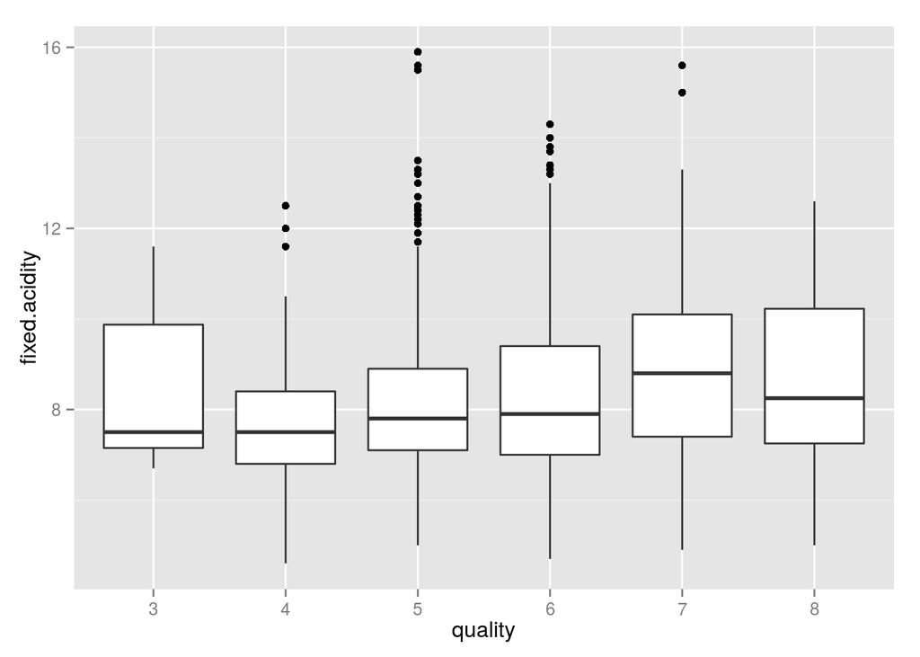

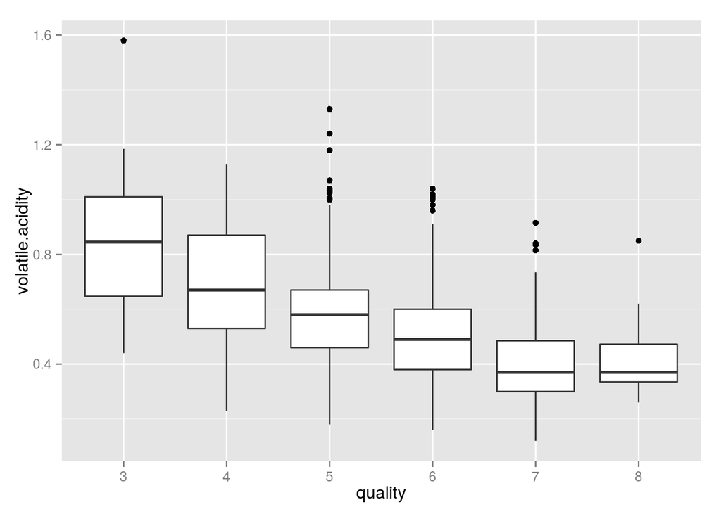

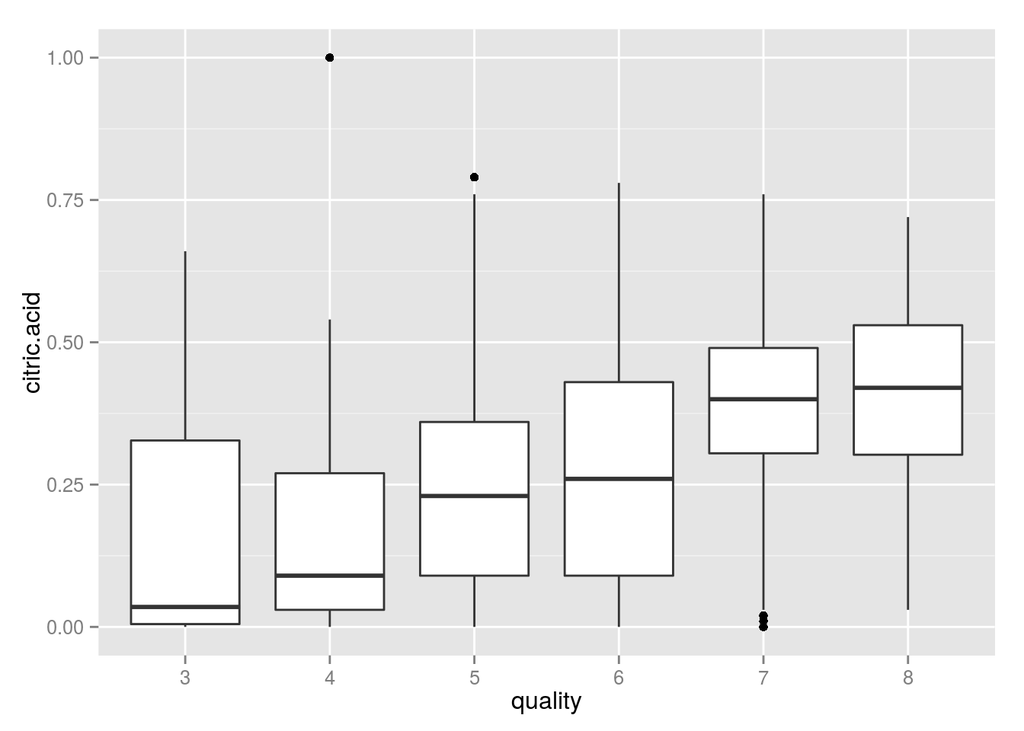